# Problem Set 5

Due date: 23 October

Please upload your completed assignment to the ELMs course site (under the assignments menu) and to your class Github repository. You need to upload both your Quarto document (with R code, as needed) and its rendered output (either as a PDF or HTML file).

**Total points: 25**

```r
library(scales)
```

## Question 1

*Total points: 6*

Use the data in the table below to answer the following questions.

Voting by Age in 2000

| Age group | Non-voters | Voters | Total |
| --- | --- | --- | --- |
| 18-24 | 70 | 50 | 120 |
| 25-30 | 40 | 50 | 90 |
| 31 and up | 220 | 570 | 790 |
| TOTAL | 330 | 670 | 1000 |

### Part A

*Points: 2*

**Note**

2/2

What is the probability of being 25-30 or a non-voter?

```r
(90/1000)+(330/1000)-(40/1000)
```

```
[1] 0.38
```

Answer: P(25-30 or non-voter) = P(25-30) + P(non-voter) - P (25-30 & non-voter) = 38%

### Part B

*Points: 4*

**Note**

1/4

Assuming a normal distribution, report the 95% confidence intervals for the percentage of 18-to-24-year-olds who did not vote, and then the percentage of 25-to-30-year-olds who did not vote.

```r
70/120 # sample proportion p_hat
```

```
[1] 0.5833333
```

```r
se_1 <- sqrt((70/120)*(1-70/120)/120) # s.e.
70/120 + 1.96*se_1
```

```
[1] 0.6715434
```

```r
70/120 - 1.96*se_1
```

```
[1] 0.4951233
```

Answer_1: The 95% CIs for the percentage of 18-24 years old who did not vote is 0.495 to 0.671

```r
se_2 <- sqrt((40/90)*(1-40/90)/90) # s.e.
40/90 + 1.96*se_2
```

```
[1] 0.5471059
```

```r
40/90 - 1.96*se_2
```

```
[1] 0.341783
```

Answer_2: The 95% CIs for the percentage of 25-30 years old who did not vote is 0.342 to 0.547

**Tip**

The probability that an individual is 18-to-24 and a non-voter is not conditional. Therefore, you look at the proportion of the whole population who meet those criteria.

$$\hat{p} = Pr(18\ to\ 24 \& NV) = \frac{70}{1000} = 0.07$$

And:

$$n = 1000$$

Therefore:

$$SE(\hat{p}) = \sqrt{\frac{0.07 * 0.93}{1000}} = 0.008068457$$

The 95% confidence interval can be found:

$$\hat{p} \pm 1.96*SE(\hat{p})$$

Therefore, the 95% confidence interval for the percentage of 18-to-24-year-olds who did not vote is 5.42% to 8.58%.

Using the same method, the 95% confidence intervals for the percentage of 25-to-30-year-olds who did not vote is 2.79% to 5.21%.

## Question 2

*Total points:* *7*

Assume that the standard deviation for the population distribution of a state in which you want to conduct a poll is 200.

### Part A

*Points: 3*

**Note**

3/3

Calculate the spread of the sampling distribution for each of the following sample sizes: 1, 4, 25, 100, 250, 1000, 5,000, and 10,000.

```r
# spread of the sampling distribution is the standard deviation of the sampling distrution, s.d.(samp_dist)= s.d.(pop_dist)/sqrt(n)
200/sqrt(1)
```

```
[1] 200
```

```r
200/sqrt(4)
```

```
[1] 100
```

```r
200/sqrt(25)
```

```
[1] 40
```

```r
200/sqrt(100)
```

```
[1] 20
```

```r
200/sqrt(250)
```

```
[1] 12.64911
```

```r
200/sqrt(1000)
```

```
[1] 6.324555
```

```r
200/sqrt(5000)
```

```
[1] 2.828427
```

```r
200/sqrt(10000)
```

```
[1] 2
```

Answer: The standard deviation of the sampling distribution is as follows: 200, 100, 40, 20, 12.65, 6.32, 2.83, and 2.

### Part B

*Points: 1*

**Note**

1/1

Describe specifically how the variability of the sampling distribution changes as the sample size varies. Considering the expense of running a poll, which sample size do you think is most optimal if conducting the poll?

Answer: As the sample size expands, the variability of the sampling distribution goes down. For practical purposes (accuracy) of conducting a poll, 5,000 seems the best pick; while if there are further budgetary constraints, 1,000 may be the second best choice as the standard error is larger.

### Part C

*Points: 3*

**Note**

3/3

Display your results graphically (using R) with the sample size on the x-axis and the standard error (of the sampling distribution) on the y-axis.

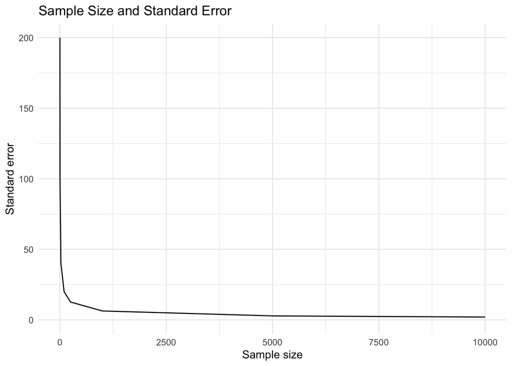

```r
library(ggplot2)

sample <- c(1, 4, 25, 100, 250, 1000, 5000, 10000)
sd <- 200
se <- sd / sqrt(sample)
data <- data.frame(x = sample, y = se)

ggplot(data, aes(x = x, y = y)) +
  geom_density(stat="identity") +
  labs(title = "Sample Size and Standard Error",
       x = "Sample size", y = "Standard error") +
  theme_minimal()
```

## Question 3

*Points: 4*

**Note**

4/4

Suppose you conduct a survey (to generate a sample mean of interest) and find that it has a margin of error of 4.5 with a sample size of 900 using a 95% confidence interval. What would the margin of error be for a 90% confidence interval?

```r
1.645*(sqrt(900*(4.5^2)/(1.96^2))/sqrt(900))
```

```
[1] 3.776786
```

Answer: The margin of error for a 90% CI is 3.78

## Question 4

*Points: 4*

**Note**

4/4

Assume that, in State A, the mean income in the population is $20,000 with a standard deviation of $2,000. If you took an SRS of 900 individuals from that population, what is the probability that you would get a sample mean income of $20,200 or greater? What would be the probability if the sample size was only 25?

**Note**

Assume a normal distribution for both questions.

```r
se_41 <- 2000/sqrt(900)
se_42 <- 2000/sqrt(25)
z_41 <- (20200-20000)/se_41
z_42 <- (20200-20000)/se_42
# For a sample size of 900, P(X>20200) = P(Z>3) = 1-P(Z<=3) = 1-.9987 = 0.0013
# For a sample size of 25, P(X>20200) = P(Z>0.5) = 1-P(Z<=0.5) = 1-.6915 = 0.3085
# I got the normal distribution table from
# https://www.r-bloggers.com/2013/10/generating-your-own-normal-distribution-table/
```

Answer: For a sample size of 900, the probability of getting a sample mean larger than $20,200 is 0.13%, while for a sample size of 25, the probability of getting a sample mean larger than $20,200 is 30.85% (assuming normal distribution for both).

## Question 5

*Points: 4*

**Note**

4/4

Assume that a coin is fair. If I flip a coin 500 times, what is a 95% confidence interval for the range of the count of heads that I will get? What if I flip the coin 5,000 times? What about 50,000 times?

```r
(0.5 + 1.96*sqrt((0.5)*(1-0.5)/500))*500
```

```
[1] 271.9135
```

```r
(0.5 - 1.96*sqrt((0.5)*(1-0.5)/500))*500
```

```
[1] 228.0865
```

Answer_1: The 95% CI with 500 flips for heads is from 228 to 272 counts.

```r
(0.5 + 1.96*sqrt((0.5)*(1-0.5)/5000))*5000
```

```
[1] 2569.296
```

```r
(0.5 - 1.96*sqrt((0.5)*(1-0.5)/5000))*5000
```

```
[1] 2430.704
```

Answer_2: The 95% CI with 5,000 flips for heads is from 2,431 to 2,569 counts.

```r
(0.5 + 1.96*sqrt((0.5)*(1-0.5)/50000))*50000
```

```
[1] 25219.13
```

```r
(0.5 - 1.96*sqrt((0.5)*(1-0.5)/50000))*50000
```

```
[1] 24780.87
```

Answer_3: The 95% CI with 50,000 flips for heads is from 24,781 to 25,219 counts.